# Prosper Loan Data Exploration

## Preliminary Wrangling

```python
# import all packages and set plots to be embedded inline
import numpy as np
import pandas as pd
import matplotlib.pyplot as plt
import seaborn as sns

sns.set(font_scale=.75)
sns.set_style("whitegrid")

%matplotlib inline
```

```python
df = pd.read_csv("prosperLoanData.csv")
```

```python
df.head()
```

|  | ListingKey | ListingNumber | ListingCreationDate | CreditGrade | Term | LoanStatus | ClosedDate | BorrowerAPR | BorrowerRate | LenderYield | ... | LP_ServiceFees | LP_CollectionFees | LP_GrossPrincipalLoss | LP_NetPrincipalLoss | LP_NonPrincipalRecoverypayments | PercentFunded | Recommendations | InvestmentFromFriendsCount | InvestmentFromFriendsAmount | Investors |
| --- | --- | --- | --- | --- | --- | --- | --- | --- | --- | --- | --- | --- | --- | --- | --- | --- | --- | --- | --- | --- | --- |
| 0 | 1021339766868145413AB3B | 193129 | 2007-08-26 19:09:29.263000000 | C | 36 | Completed | 2009-08-14 00:00:00 | 0.16516 | 0.1580 | 0.1380 | ... | -133.18 | 0.0 | 0.0 | 0.0 | 0.0 | 1.0 | 0 | 0 | 0.0 | 258 |
| 1 | 10273602499503308B223C1 | 1209647 | 2014-02-27 08:28:07.900000000 | NaN | 36 | Current | NaN | 0.12016 | 0.0920 | 0.0820 | ... | 0.00 | 0.0 | 0.0 | 0.0 | 0.0 | 1.0 | 0 | 0 | 0.0 | 1 |
| 2 | 0EE9337825851032864889A | 81716 | 2007-01-05 15:00:47.090000000 | HR | 36 | Completed | 2009-12-17 00:00:00 | 0.28269 | 0.2750 | 0.2400 | ... | -24.20 | 0.0 | 0.0 | 0.0 | 0.0 | 1.0 | 0 | 0 | 0.0 | 41 |
| 3 | 0EF5356002482715299901A | 658116 | 2012-10-22 11:02:35.010000000 | NaN | 36 | Current | NaN | 0.12528 | 0.0974 | 0.0874 | ... | -108.01 | 0.0 | 0.0 | 0.0 | 0.0 | 1.0 | 0 | 0 | 0.0 | 158 |
| 4 | 0F023589499656230C5E3E2 | 909464 | 2013-09-14 18:38:39.097000000 | NaN | 36 | Current | NaN | 0.24614 | 0.2085 | 0.1985 | ... | -60.27 | 0.0 | 0.0 | 0.0 | 0.0 | 1.0 | 0 | 0 | 0.0 | 20 |

5 rows × 81 columns

```python
df.info()
```

```
<class 'pandas.core.frame.DataFrame'>
RangeIndex: 113937 entries, 0 to 113936
Data columns (total 81 columns):
 #   Column                               Non-Null Count   Dtype
---  ------                               --------------   -----
 0   ListingKey                           113937 non-null  object
 1   ListingNumber                        113937 non-null  int64
 2   ListingCreationDate                  113937 non-null  object
 3   CreditGrade                          28953 non-null   object
 4   Term                                 113937 non-null  int64
 5   LoanStatus                           113937 non-null  object
 6   ClosedDate                           55089 non-null   object
 7   BorrowerAPR                          113912 non-null  float64
 8   BorrowerRate                         113937 non-null  float64
 9   LenderYield                          113937 non-null  float64
```

[output cut: 73 more lines]

```python
df.describe()
```

|  | ListingNumber | Term | BorrowerAPR | BorrowerRate | LenderYield | EstimatedEffectiveYield | EstimatedLoss | EstimatedReturn | ProsperRating (numeric) | ProsperScore | ... | LP_ServiceFees | LP_CollectionFees | LP_GrossPrincipalLoss | LP_NetPrincipalLoss | LP_NonPrincipalRecoverypayments | PercentFunded | Recommendations | InvestmentFromFriendsCount | InvestmentFromFriendsAmount | Investors |
| --- | --- | --- | --- | --- | --- | --- | --- | --- | --- | --- | --- | --- | --- | --- | --- | --- | --- | --- | --- | --- | --- |
| count | 1.139370e+05 | 113937.000000 | 113912.000000 | 113937.000000 | 113937.000000 | 84853.000000 | 84853.000000 | 84853.000000 | 84853.000000 | 84853.000000 | ... | 113937.000000 | 113937.000000 | 113937.000000 | 113937.000000 | 113937.000000 | 113937.000000 | 113937.000000 | 113937.000000 | 113937.000000 | 113937.000000 |
| mean | 6.278857e+05 | 40.830248 | 0.218828 | 0.192764 | 0.182701 | 0.168661 | 0.080306 | 0.096068 | 4.072243 | 5.950067 | ... | -54.725641 | -14.242698 | 700.446342 | 681.420499 | 25.142686 | 0.998584 | 0.048027 | 0.023460 | 16.550751 | 80.475228 |
| std | 3.280762e+05 | 10.436212 | 0.080364 | 0.074818 | 0.074516 | 0.068467 | 0.046764 | 0.030403 | 1.673227 | 2.376501 | ... | 60.675425 | 109.232758 | 2388.513831 | 2357.167068 | 275.657937 | 0.017919 | 0.332353 | 0.232412 | 294.545422 | 103.239020 |
| min | 4.000000e+00 | 12.000000 | 0.006530 | 0.000000 | -0.010000 | -0.182700 | 0.004900 | -0.182700 | 1.000000 | 1.000000 | ... | -664.870000 | -9274.750000 | -94.200000 | -954.550000 | 0.000000 | 0.700000 | 0.000000 | 0.000000 | 0.000000 | 1.000000 |
| 25% | 4.009190e+05 | 36.000000 | 0.156290 | 0.134000 | 0.124200 | 0.115670 | 0.042400 | 0.074080 | 3.000000 | 4.000000 | ... | -73.180000 | 0.000000 | 0.000000 | 0.000000 | 0.000000 | 1.000000 | 0.000000 | 0.000000 | 0.000000 | 2.000000 |
| 50% | 6.005540e+05 | 36.000000 | 0.209760 | 0.184000 | 0.173000 | 0.161500 | 0.072400 | 0.091700 | 4.000000 | 6.000000 | ... | -34.440000 | 0.000000 | 0.000000 | 0.000000 | 0.000000 | 1.000000 | 0.000000 | 0.000000 | 0.000000 | 44.000000 |
| 75% | 8.926340e+05 | 36.000000 | 0.283810 | 0.250000 | 0.240000 | 0.224300 | 0.112000 | 0.116600 | 5.000000 | 8.000000 | ... | -13.920000 | 0.000000 | 0.000000 | 0.000000 | 0.000000 | 1.000000 | 0.000000 | 0.000000 | 0.000000 | 115.000000 |
| max | 1.255725e+06 | 60.000000 | 0.512290 | 0.497500 | 0.492500 | 0.319900 | 0.366000 | 0.283700 | 7.000000 | 11.000000 | ... | 32.060000 | 0.000000 | 25000.000000 | 25000.000000 | 21117.900000 | 1.012500 | 39.000000 | 33.000000 | 25000.000000 | 1189.000000 |

8 rows × 61 columns

### What is the structure of your dataset?

The dataset involves information on 113937 loans and their borrowers represented using 81 features. The features are mostly of categorical and numerical types.

### What is/are the main feature(s) of interest in your dataset?

The dataset contains a large number of features related to the borrwer themselves including, financial situation, type of loan, history of loans, etc. It would be possible to analyse what features correlate with which loan outcome status.

### Data Cleaning

- Keeping features needed for investigation

```python
df_clean = df[["LoanStatus", "ProsperScore", "ListingCategory (numeric)",
               "EmploymentStatus", "EmploymentStatusDuration", "IsBorrowerHomeowner",
               "OpenRevolvingAccounts", "DebtToIncomeRatio", "IncomeRange", "LoanOriginalAmount"]]
```

```python
df_clean.info()
```

```
<class 'pandas.core.frame.DataFrame'>
RangeIndex: 113937 entries, 0 to 113936
Data columns (total 10 columns):
 #   Column                     Non-Null Count   Dtype
---  ------                     --------------   -----
 0   LoanStatus                 113937 non-null  object
 1   ProsperScore               84853 non-null   float64
 2   ListingCategory (numeric)  113937 non-null  int64
 3   EmploymentStatus           111682 non-null  object
 4   EmploymentStatusDuration   106312 non-null  float64
 5   IsBorrowerHomeowner        113937 non-null  bool
 6   OpenRevolvingAccounts      113937 non-null  int64
 7   DebtToIncomeRatio          105383 non-null  float64
 8   IncomeRange                113937 non-null  object
 9   LoanOriginalAmount         113937 non-null  int64
dtypes: bool(1), float64(3), int64(3), object(3)
memory usage: 7.9+ MB
```

- Removing the chain assignment warning produced from using *fillna()*, from [*here*](https://stackoverflow.com/questions/20625582/how-to-deal-with-settingwithcopywarning-in-pandas)

```python
pd.options.mode.chained_assignment = None  # default='warn'
```

```python
df_clean["LoanStatus"].value_counts()
```

```
Current                   56576
Completed                 38074
Chargedoff                11992
Defaulted                  5018
Past Due (1-15 days)        806
Past Due (31-60 days)       363
Past Due (61-90 days)       313
Past Due (91-120 days)      304
Past Due (16-30 days)       265
FinalPaymentInProgress      205
Past Due (>120 days)         16
Cancelled                     5
Name: LoanStatus, dtype: int64
```

```python
# Renames values that contain the string "Past Due" to "Past Due"
df_clean["LoanStatus"] = df_clean["LoanStatus"].apply(lambda x: x if "Past Due" not in x else "Past Due")
```

- Removing the status *Cancelled* as it froms only 0.0044% of of loans (5 loans) and would be impossible to properly analyse

```python
df_clean = df_clean[df_clean["LoanStatus"] != "Cancelled"]
df_clean["LoanStatus"].unique()
```

```
array(['Completed', 'Current', 'Past Due', 'Defaulted', 'Chargedoff',
       'FinalPaymentInProgress'], dtype=object)
```

- Creating a **ListingCategory** feature to contain **ListingCategory (numeric)**'s string counterparts

```python
listingcategory_dict = {0 : "Not Available", 1 : "Debt Consolidation", 2 : "Home Improvement",
                        3: "Business", 4 : "Personal Loan", 5 : "Student Use", 6 : "Auto",
                        7 : "Other", 8 : "Baby&Adoption", 9 : "Boat", 10 : "Cosmetic Procedure",
                        11 : "Engagement Ring", 12 : "Green Loans", 13 : "Household Expenses",
                        14 : "Large Purchases", 15 : "Medical/Dental", 16 : "Motorcycle",
                        17 : "RV", 18 : "Taxes", 19 : "Vacation", 20 : "Wedding Loans"}

df_clean["ListingCategory"] = df_clean['ListingCategory (numeric)'].map(listingcategory_dict)
df_clean["ListingCategory"].unique()
```

```
array(['Not Available', 'Home Improvement', 'Motorcycle',
       'Debt Consolidation', 'Other', 'Household Expenses', 'Auto',
       'Medical/Dental', 'Wedding Loans', 'Vacation', 'Business', 'Taxes',
       'Baby&Adoption', 'Personal Loan', 'Engagement Ring',
       'Large Purchases', 'Student Use', 'Boat', 'RV',
       'Cosmetic Procedure', 'Green Loans'], dtype=object)
```

- Replacing null values in **EmploymentStatus** with *Not available*

```python
df_clean["EmploymentStatus"].unique()
```

```
array(['Self-employed', 'Employed', 'Not available', 'Full-time', 'Other',
       nan, 'Not employed', 'Part-time', 'Retired'], dtype=object)
```

```python
df_clean["EmploymentStatus"].fillna("Not available", inplace = True)
df_clean["EmploymentStatus"].isnull().value_counts()
```

```
False    113932
Name: EmploymentStatus, dtype: int64
```

### Misc. Functions

- Bar plot annotation code from [*here*](https://datavizpyr.com/how-to-annotate-bars-in-barplot-with-matplotlib-in-python/)

```python
# For vertical bar graphs
def annotate_vbar(_ax, _format):
    ymin, ymax = plt.ylim()
    plt.ylim(ymin*1.075, ymax*1.075) # To create empty space for the annotation
    for p in _ax.patches:
        _ax.annotate(format(p.get_height(), _format),
                     (p.get_x() + p.get_width() / 2., p.get_height()),
                     ha = 'center', va = 'center',
                     xytext = (0, 9),textcoords = 'offset points')

# For horizontal bar graphs
def annotate_hbar(_ax, _format):
    xmin, xmax = plt.xlim()
    plt.xlim(xmin*1.075, xmax*1.075) # To create empty space for the annotation
    for p in _ax.patches:
        _ax.annotate(format(p.get_width(), _format),
                     (p.get_width(), p.get_y() + p.get_height() / 2.),
                     ha = 'center', va = 'center',
                     xytext = (18, 0),textcoords = 'offset points')
```

```python
# Orders given series by its value counts
def orderbycount(_series, reverse = False):
    if(reverse):
        return _series.value_counts().index[::-1]
    else:
        return _series.value_counts().index
```

```python
# returns series showing only top '_cnt' categories and groups the rest into one
def showonly(_cnt, _series):
    tmp = _series.value_counts()
    tmp2 = tmp.head(_cnt)
    if len(tmp) > _cnt:
        tmp2['remaining {0} categories'.format(len(tmp) - _cnt)] = sum(tmp[_cnt:])
    return tmp2
```

## Univariate Exploration

### **LoanStatus** univariate exploration

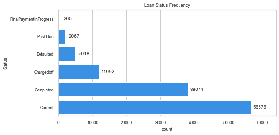

```python
plt.figure(figsize=(8,4))
ax = sns.countplot(data = df_clean, y = "LoanStatus", color = "dodgerblue", order = orderbycount(df_clean["LoanStatus"], True))
ax.set_title("Loan Status Frequency")
annotate_hbar(ax, ".0f")
plt.ylabel("Status");
```

```python
df_clean["LoanStatus"].value_counts(normalize = True)
```

```
Current                   0.496577
Completed                 0.334182
Chargedoff                0.105256
Defaulted                 0.044044
Past Due                  0.018142
FinalPaymentInProgress    0.001799
Name: LoanStatus, dtype: float64
```

#### Items of Note:

- 83.1% of loans are *Current* or *Completed*
- 14.9% of loans have been *Chargedoff* or *Defaulted*
- 1.8% of loans are *Past Due*

### Prosper Score unvariate exploration

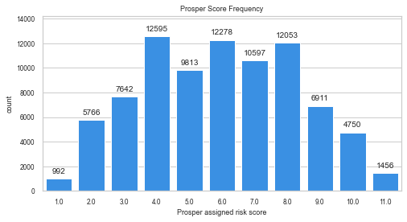

```python
plt.figure(figsize=(8,4))
ax = sns.countplot(data = df_clean, x = "ProsperScore", color = "dodgerblue")
ax.set_title("Prosper Score Frequency")
annotate_vbar(ax, ".0f")
plt.xlabel("Prosper assigned risk score");
```

```python
df_clean["ProsperScore"].value_counts(normalize = True)
```

```
4.0     0.148433
6.0     0.144697
8.0     0.142046
7.0     0.124887
5.0     0.115647
3.0     0.090062
9.0     0.081447
2.0     0.067953
10.0    0.055979
11.0    0.017159
1.0     0.011691
Name: ProsperScore, dtype: float64
```

##### Items of Note:

- 97.1% of values lie between scores of *2* and *10*
- The scores are distributed normally

### Listing Category univariate exploration

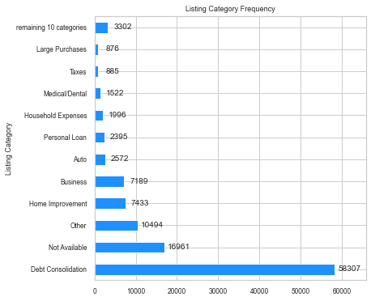

```python
plt.figure(figsize=(6,6))
ax = showonly(11, df_clean["ListingCategory"]).plot(kind = "barh", color = "dodgerblue")
ax.set_title("Listing Category Frequency")
annotate_hbar(ax, ".0f")
plt.ylabel("Listing Category");
```

```python
df_clean["ListingCategory"].value_counts(normalize = True)
```

```
Debt Consolidation    0.511770
Not Available         0.148870
Other                 0.092108
Home Improvement      0.065241
Business              0.063099
Auto                  0.022575
Personal Loan         0.021021
Household Expenses    0.017519
Medical/Dental        0.013359
Taxes                 0.007768
Large Purchases       0.007689
Wedding Loans         0.006767
Vacation              0.006741
Student Use           0.006636
Motorcycle            0.002668
Engagement Ring       0.001905
Baby&Adoption         0.001747
Cosmetic Procedure    0.000799
Boat                  0.000746
Green Loans           0.000518
RV                    0.000456
Name: ListingCategory, dtype: float64
```

### Employment Status univariate exploration

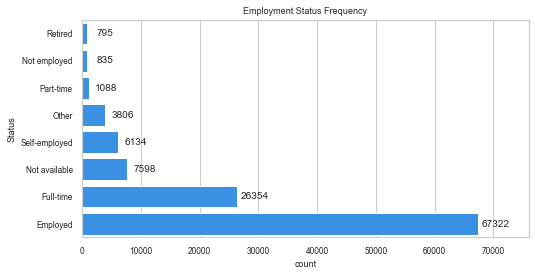

```python
plt.figure(figsize=(8,4))
ax = sns.countplot(data = df_clean, y = "EmploymentStatus", color = "dodgerblue", order = orderbycount(df_clean["EmploymentStatus"], True))
ax.set_title("Employment Status Frequency")
annotate_hbar(ax, ".0f")
plt.ylabel("Status");
```

```python
df_clean["EmploymentStatus"].value_counts(normalize = True)
```

```
Employed         0.590896
Full-time        0.231313
Not available    0.066689
Self-employed    0.053839
Other            0.033406
Part-time        0.009550
Not employed     0.007329
Retired          0.006978
Name: EmploymentStatus, dtype: float64
```

##### Items of Note:

- Most of the borrowers are in some form of employment, 88.6%
- The feature **EmploymentStatusDuration** would not provide useful information if explored univariately as it is dependent on **EmploymentStatus**

### Is Borrower Homeowner univariate exploration

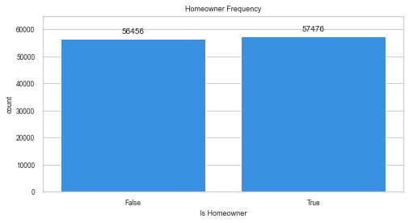

```python
plt.figure(figsize=(8,4))
ax = sns.countplot(data = df_clean, x = "IsBorrowerHomeowner", color = "dodgerblue")
ax.set_title("Homeowner Frequency")
annotate_vbar(ax, ".0f")
plt.xlabel("Is Homeowner");
```

##### Items of Note:

- There is only about 1000 difference in the counts
- Distribution is nearly even

### Open Revolving Accounts univariate exploration

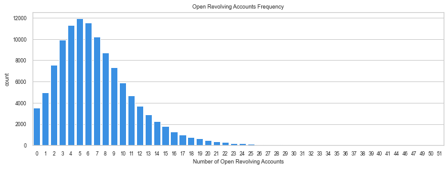

```python
plt.figure(figsize=(12,4))
ax = sns.countplot(data = df_clean, x = "OpenRevolvingAccounts", color = "dodgerblue")
ax.set_title("Open Revolving Accounts Frequency")
plt.xlabel("Number of Open Revolving Accounts");
```

##### Items of Note:

- Most borrowers have 13 or less open revolving accounts

### Debt To Income Ratio univariate exploration

```python
df_clean["DebtToIncomeRatio"].describe()
```

```
count    105378.000000
mean          0.275952
std           0.551771
min           0.000000
25%           0.140000
50%           0.220000
75%           0.320000
max          10.010000
Name: DebtToIncomeRatio, dtype: float64
```

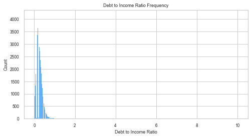

```python
plt.figure(figsize=(8,4))
ax = sns.histplot(data = df_clean, x = "DebtToIncomeRatio", color = "dodgerblue")
plt.title("Debt to Income Ratio Frequency")
plt.xlabel("Debt to Income Ratio");
```

- Most of the values are between 0 and 1.5. Zooming is required for a clearer graph

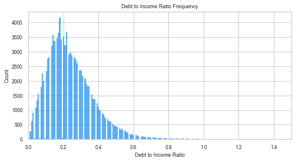

```python
plt.figure(figsize=(8,4))
ax = sns.histplot(data = df_clean, x = "DebtToIncomeRatio", color = "dodgerblue")
plt.title("Debt to Income Ratio Frequency")
plt.xlabel("Debt to Income Ratio");
plt.xlim(0,1.5);
```

##### Items of Note:

- Nearly all borrowers have a Debt to Income Ratio between *0.0* and *0.8*

### Income Range univariate exploration

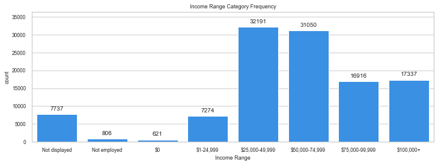

```python
incomerange_order = ["Not displayed", "Not employed", "$0", "$1-24,999", "$25,000-49,999", "$50,000-74,999", "$75,000-99,999", "$100,000+"]
plt.figure(figsize=(12,4))
ax = sns.countplot(data = df_clean, x = "IncomeRange", color = "dodgerblue", order = incomerange_order)
ax.set_title("Income Range Category Frequency")
annotate_vbar(ax, ".0f")
plt.xlabel("Income Range");
```

```python
df_clean["IncomeRange"].value_counts(normalize = True)
```

```
$25,000-49,999    0.282546
$50,000-74,999    0.272531
$100,000+         0.152170
$75,000-99,999    0.148475
Not displayed     0.067909
$1-24,999         0.063845
Not employed      0.007074
$0                0.005451
Name: IncomeRange, dtype: float64
```

##### Items of Note:

- Most borrowers are within the $25,000+ margin, 85.6%

### Loan Original Amount univariate exploration

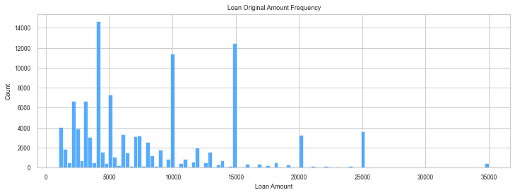

```python
plt.figure(figsize=(12,4))
ax = sns.histplot(data = df_clean, x = "LoanOriginalAmount", color = "dodgerblue")
plt.title("Loan Original Amount Frequency")
plt.xlabel("Loan Amount");
```

```python
df_clean["LoanOriginalAmount"].describe()
```

```
count    113932.000000
mean       8337.305121
std        6245.780197
min        1000.000000
25%        4000.000000
50%        6500.000000
75%       12000.000000
max       35000.000000
Name: LoanOriginalAmount, dtype: float64
```

##### Items of Note:

- There is a lower number of loans with original amounts greater than *15000*

### Discuss the distribution(s) of your variable(s) of interest. Were there any unusual points? Did you need to perform any transformations?

- Most of the variables showed usual distributions with little abnormalities
- Most of the variables tended towards a small number of values where most of the frequency was concentrated
- Variables did not require much transformation, but **DebtToIncomeRatio** has possible outliers, so zooming was required to clearly illustrate the distribution

### Of the features you investigated, were there any unusual distributions? Did you perform any operations on the data to tidy, adjust, or change the form of the data? If so, why did you do this?

- Most operations done to tidy the data was for properly ordering categories
  - To better illustrate the distribution if the categories are related
- For **DebtToIncomeRatio** zooming on the x-axis was required to better illustrate the distribution
  - The maximum value was 10.01 even though the third quartile was 0.32
  - This lead to alot of information to be squeezed into a small portion of the graph

## Bivariate Exploration

- The main focus will be **LoanStatus** and how the other features relate to it.

```python
# Used to make order consistent with different variables throughout the analysis
loanstatus_order = ["Completed", "Current", "Past Due", "Defaulted", "Chargedoff", "FinalPaymentInProgress"]
```

### Correlation Matrix Heatmap

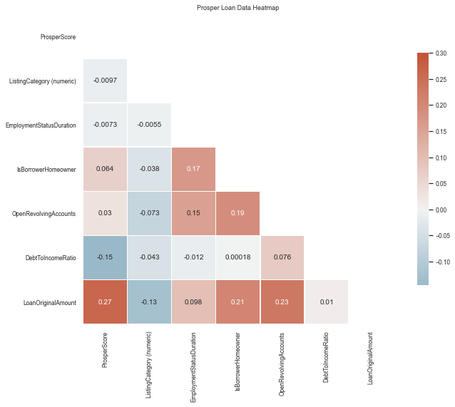

```python
# correlation matrix
correlationmatrix = df_clean.corr()

# Mask to hide upper triangle
mask = np.triu(np.ones_like(correlationmatrix, dtype=bool))

f, ax = plt.subplots(figsize=(12, 8))
cmap = sns.diverging_palette(230, 20, as_cmap=True)
ax.set_title("Prosper Loan Data Heatmap")
sns.heatmap(correlationmatrix, mask=mask, cmap=cmap, vmax=.3, center=0, annot=True, square=True, linewidths=.5, cbar_kws={"shrink": .75});
```

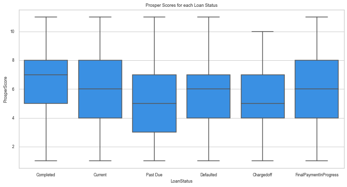

```python
plt.figure(figsize=(12, 6))
ax = sns.boxplot(data = df_clean, x = "LoanStatus", y = "ProsperScore", color = "dodgerblue", order = loanstatus_order)
plt.title("Prosper Scores for each Loan Status");
```

##### Items of Note:

- *Completed* loans tend towards a high **ProsperScore** (i.e. low risk)
- *Chargedoff* and *Past Due* loans ted towards the middle of the score
- This shows that **ProsperScore** might be good at detecting loans likely to be *Completed* but is not very sensitive to *Chargedoff* and *Past Due*

#### ListingCategory

- Showing only top 10 **ListingCategories** by count.

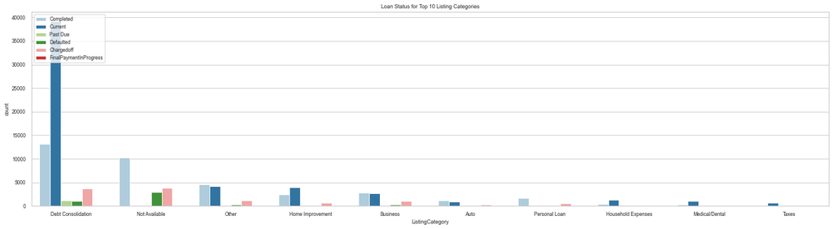

```python
plt.figure(figsize=(24, 6))
ax = sns.countplot(data = df_clean, x = "ListingCategory", hue = "LoanStatus",
                   palette = "Paired", hue_order = loanstatus_order,
                   order = df_clean["ListingCategory"].value_counts().iloc[:10].index)
ax.legend(loc = "upper left")
plt.title("Loan Status for Top 10 Listing Categories");
```

- Due to how low the count of most of the variables are, the percentage of the **LoanStatus** for each **ListingCategory** will be used to better illustrate the relationship
- For better clarity the *Not Available* category is removed, and the 20 **ListingCategories** were divided into two graphs

```python
listcategory_loanstatus = df_clean[df_clean["ListingCategory"] != "Not Available"].groupby(["ListingCategory"])["LoanStatus"].value_counts(normalize=True).mul(100).rename("percentage").reset_index()
```

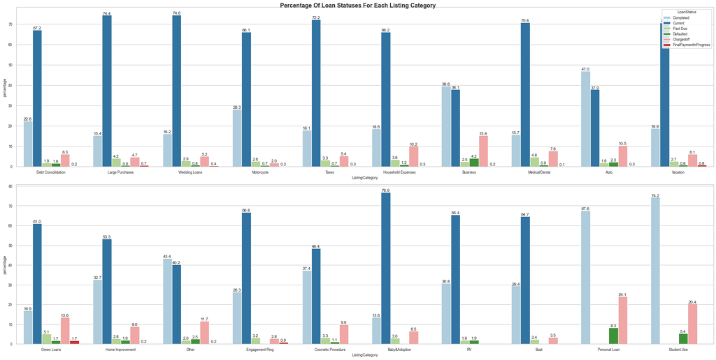

```python
fig, axs = plt.subplots(nrows=2, figsize = (24,12))

sns.barplot(x="ListingCategory", y="percentage", hue="LoanStatus",
            palette = "Paired", data=listcategory_loanstatus, hue_order = loanstatus_order,
            order = listcategory_loanstatus["ListingCategory"].value_counts().iloc[:10].index, ax = axs[0])

sns.barplot(x="ListingCategory", y="percentage", hue="LoanStatus",
            palette = "Paired", data=listcategory_loanstatus, hue_order = loanstatus_order,
            order = listcategory_loanstatus["ListingCategory"].value_counts().iloc[10:].index, ax = axs[1])

axs[1].get_legend().remove()

plt.suptitle("Percentage of Loan Statuses for each Listing Category".title(), y = 1, fontsize = 14, weight = "bold")

for ax in axs:
    for p in ax.patches:
            ax.annotate(format(p.get_height(), ".1f"),
                         (p.get_x() + p.get_width() / 2., p.get_height()),
                         ha = 'center', va = 'center',
                         xytext = (0, 4),textcoords = 'offset points')

plt.tight_layout()
```

##### Items of Note:

- Most loans are of category *Debt Consolidation* and have the status of *Current*
- *Student Use* and *Personal Loan* had interesting percentages
  - They had the highest percentages of *Completed* loans (74.2% & 67.6% respectively)
  - They also had the highest percentages of *Chargedoff* loans (20.4% & 24.1% respectively) and *Defaulted* loans (5.4% & 8.3% respectively)
- *Green Loans* and *Medical/Dental* had the highest percentages of *Past Due* loans (5.1% & 4.8% respectively)
  - It should be noted that these values are only 1-2% more than other categories
- Most of the loans in the dataset are of status *Current*, but *Personal Loan* and *Student Use* categories seem to not have much *Current* loans

#### Employment Status

```python
employmentstatus_loanstatus = df_clean.groupby(["EmploymentStatus"])["LoanStatus"].value_counts(normalize=True).mul(100).rename("percentage").reset_index()
employmentstatus_order = ["Employed", "Full-time", "Part-time", "Self-employed", "Retired", "Not employed", "Other"]
```

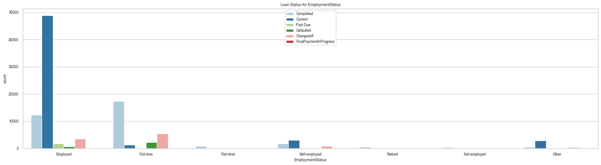

```python
plt.figure(figsize=(24, 6))
ax = sns.countplot(data = df_clean, x = "EmploymentStatus", hue = "LoanStatus",
                   palette = "Paired", hue_order = loanstatus_order,
                   order = employmentstatus_order)
ax.legend(loc = "upper center")
plt.title("Loan Status for EmploymentStatus");
```

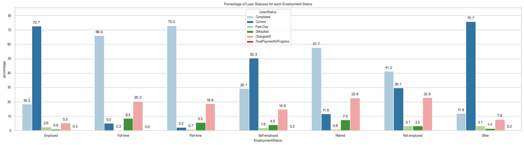

```python
plt.figure(figsize=(24, 6))
ax = sns.barplot(x="EmploymentStatus", y="percentage", hue="LoanStatus",
                 palette = "Paired", data=employmentstatus_loanstatus, hue_order = loanstatus_order,
                 order = employmentstatus_order)

plt.title("Percentage of Loan Statuses for each Employment Status");

annotate_vbar(ax, ".1f")
```

#### IsBorrowerHomeowner

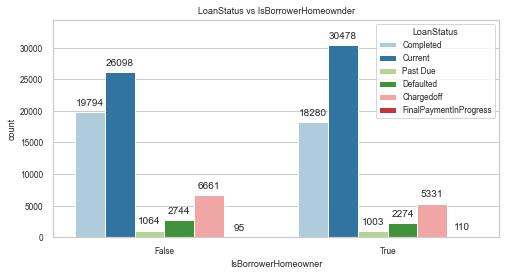

```python
plt.figure(figsize=(8, 4))
ax = sns.countplot(data = df_clean, x = "IsBorrowerHomeowner", hue = "LoanStatus", hue_order = loanstatus_order, palette = "Paired")
annotate_vbar(ax, "0.0f")
plt.title("LoanStatus vs IsBorrowerHomeownder");
```

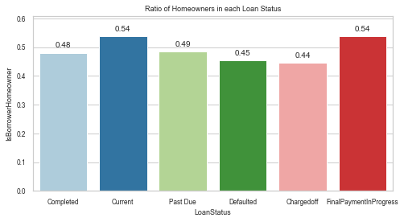

```python
plt.figure(figsize=(8, 4))
ax = sns.barplot(data = df_clean, x = "LoanStatus", y = "IsBorrowerHomeowner", palette = "Paired", ci=None, order = loanstatus_order)
annotate_vbar(ax, "0.2f")
plt.title("Ratio of Homeowners in each Loan Status");
```

##### Items of Note:

- Count distribution of **LoanStatus** over **IsBorrowerHomeownder** provided near identical distributions
  - This shows that the feature **IsBorrowerHomeowner** is unlikely to affect the **LoanStatus** significantly
- The bargraph shows that all the statuses hover around 0.5, showing that the **IsBorrowerHomeowner** has little effect on the **LoanStatus**
  - Only noticable differences are that borrowers who are not homeowners are 5% more likely to be in the *Defaulted* status and 6% more likely to be in the *Chargedoff* status but these values are not significant enought to conclude anything

#### Open Revolving Accounts

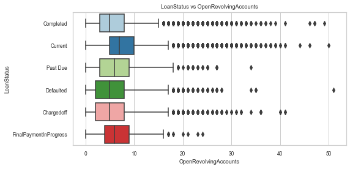

```python
plt.figure(figsize=(8, 4))
ax = sns.boxplot(data = df_clean, x = "OpenRevolvingAccounts", y = "LoanStatus", palette = "Paired", order = loanstatus_order)
plt.title("LoanStatus vs OpenRevolvingAccounts");
```

- Increasing graph clarity by zooming on borrowers with less than 25 **OpenRevolvingAccounts**

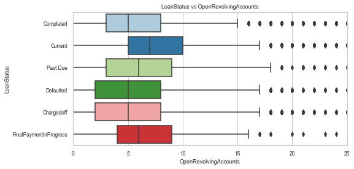

```python
plt.figure(figsize=(8, 4))
ax = sns.boxplot(data = df_clean, x = "OpenRevolvingAccounts", y = "LoanStatus", palette = "Paired", order = loanstatus_order)
plt.title("LoanStatus vs OpenRevolvingAccounts");
plt.xlim(0,25);
```

##### Items of Note:

- Differences shown in the graph are too insignificant to make proper conclusions
- The boxplots show no interesting relationship between the number of **OpenRevolvingAccounts** & **LoanStatus**

#### Debt to Income Ratio

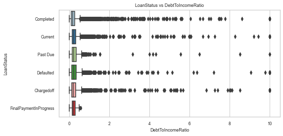

```python
plt.figure(figsize=(8, 4))
ax = sns.boxplot(data = df_clean, x = "DebtToIncomeRatio", y = "LoanStatus", palette = "Paired", order = loanstatus_order)
plt.title("LoanStatus vs DebtToIncomeRatio");
```

- Increasing graph clarity by zooming on borrowers with less than 1.5 **DebtToIncomeRatio**

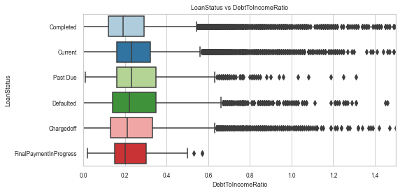

```python
plt.figure(figsize=(8, 4))
ax = sns.boxplot(data = df_clean, x = "DebtToIncomeRatio", y = "LoanStatus", palette = "Paired", order = loanstatus_order)
plt.title("LoanStatus vs DebtToIncomeRatio");
plt.xlim(0,1.5);
```

##### Items of Note:

- There is a slight tendency for *Completed* loans to have lower **DebtToIncomeRatio** than other statuses

#### Income Range

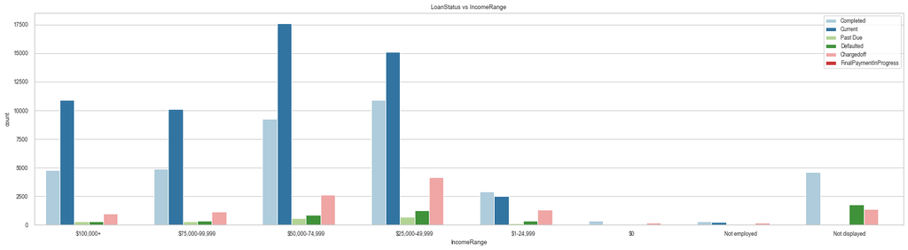

```python
plt.figure(figsize=(24, 6))
ax = sns.countplot(data = df_clean, x = "IncomeRange", hue = "LoanStatus", palette = "Paired", hue_order = loanstatus_order, order = incomerange_order[::-1])
ax.legend(loc="upper right")
plt.title("LoanStatus vs IncomeRange");
```

- Due to how low the count of most of the variables are, the percentage of the **LoanStatus** for each **IncomeRange** will be used to better illustrate the relationship

```python
incomerange_loanstatus = df_clean.groupby(["IncomeRange"])["LoanStatus"].value_counts(normalize=True).mul(100).rename("percentage").reset_index()
```

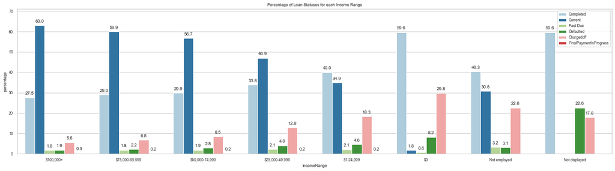

```python
plt.figure(figsize=(24, 6))
ax = sns.barplot(x="IncomeRange", y="percentage", hue="LoanStatus",
                 palette = "Paired", data=incomerange_loanstatus,
                 hue_order = loanstatus_order, order = incomerange_order[::-1])
ax.legend(loc="upper right")
plt.title("Percentage of Loan Statuses for each Income Range");
annotate_vbar(ax, ".1f")
```

##### Items of Note:

- Borrowers in the *0$* **IncomeRange** showed interesting percentages
  - They have the highest likelihood of having the *Completed* status (59.6%)
  - They also have the highest likelihood of having the *Chargedoff* status (29.8%)
- Borrowers who have not displayed their **IncomeRange** seem to be significantly more likely to have a *Defaulted* loan (22.6%)
- Borrowers who are *Not employed* have the highest likelihood of having the *Past Due* status, but that is only about 1% higher than other **Income Ranges**

#### Loan Original Amount

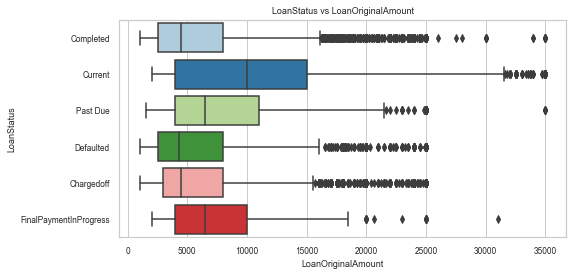

```python
plt.figure(figsize=(8, 4))
ax = sns.boxplot(data = df_clean, x = "LoanOriginalAmount", y = "LoanStatus", palette = "Paired", order = loanstatus_order)
plt.title("LoanStatus vs LoanOriginalAmount");
```

##### Items of Note:

- Borrowers with a higher **LoanOriginalAmount** seem to be more likely to be *Past Due* on the loan than have it *Completed*
- *Completed*, *Defaulted*, and *Chargedoff* loans have very similar boxplots
  - Quartiles are very similar
  - Large number of outliers

### Talk about some of the relationships you observed in this part of the investigation. How did the feature(s) of interest vary with other features in the dataset?

- **ProsperScore** might be good at detecting loans likely to be *Completed* but is not very sensitive to *Chargedoff* and *Past Due*
- The **ListingCategories** *Student Use* and *Personal Loan* had the highest percentages of *Completed* loans (74.2% & 67.6% respectively) but also the highest percentages of *Chargedoff* loans (20.4% & 24.1% respectively) and *Defaulted* loans (5.4% & 8.3% respectively)
- Borrowers with a higher **LoanOriginalAmount** seem to be more likely to be *Past Due* on the loan than have it *Completed*

### Did you observe any interesting relationships between the other features (not the main feature(s) of interest)?

- The correlation matrix heatmap gave a bit of insight into how the numeric features may be realted
- The ratio of **LoanStatuses** seem to be generally consistent in the highest frequency values in features

## Multivariate Exploration

### Employment Status, its Duration, and Loan Status

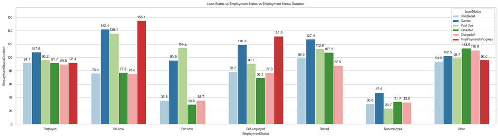

```python
plt.figure(figsize=(24, 6))
ax = sns.barplot(x="EmploymentStatus", y="EmploymentStatusDuration", hue="LoanStatus",
                 palette="Paired", data=df_clean, hue_order=loanstatus_order,
                 order=employmentstatus_order, ci=None)

plt.title("Loan Status vs Employment Status vs Employment Status Duration");

annotate_vbar(ax, ".1f")
```

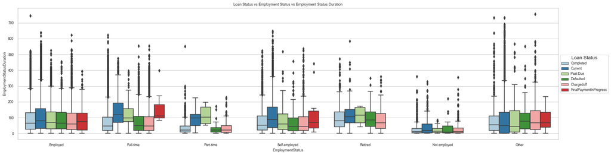

```python
plt.figure(figsize=(24, 6))
ax = sns.boxplot(x="EmploymentStatus", y="EmploymentStatusDuration", hue="LoanStatus",
                 palette="Paired", data=df_clean, hue_order=loanstatus_order,
                 order=employmentstatus_order)

plt.legend(loc="center left", bbox_to_anchor=(1, .5), title="Loan Status", title_fontsize=12)


plt.title("Loan Status vs Employment Status vs Employment Status Duration");
```

### Were there any interesting or surprising interactions between features?

- There was little interesting interactions from the multivariate analysis
- A significant portion of the durations in **EmploymentStatusDuration** showed as outliers in the boxplot